# Thresher and R2 Analysis on Matched TCGA Data - Medoids Instead of Scores

Amir Asiaee, Zach Abrams, Kevin R. Coombes

2023-03-23

# Getting Started

First, we load some global information about where to find data folders.

```r
rm(list=ls())
library(cmapR)
source("00-paths.R")
```

We load the matched TCGA data (has both mRNA and miRdata):

```r
load(file = file.path(paths$clean, "matchedData.Rda"))
dim(mRNAdata)
```

```
## [1] 20289  8895
```

```r
namesMrnaAll <- rownames(mRNAdata)
save(namesMrnaAll, file = file.path(paths$scratch, "allMrnaNames.Rda"))
dim(miRdata)
```

```
## [1] 1146 8895
```

```r
rownames(miRdata)[sample(nrow(miRdata))[1:20]]
```

```
##  [1] "hsa-miR-3611"    "hsa-miR-551b-3p" "hsa-miR-26b-3p"  "hsa-miR-3615"
##  [5] "hsa-miR-1282"    "hsa-miR-515-5p"  "hsa-miR-489-3p"  "hsa-miR-96-5p"
##  [9] "hsa-miR-3139"    "hsa-miR-542-3p"  "hsa-miR-933"     "hsa-miR-596"
## [13] "hsa-miR-302c-3p" "hsa-miR-609"     "hsa-miR-377-3p"  "hsa-miR-936"
## [17] "hsa-miR-1200"    "hsa-miR-30b-3p"  "hsa-miR-19a-5p"  "hsa-miR-374b-3p"
```

You see that we have directionality for mature miRNAs, which is missing in the GTEx data. As far as I can tell the abundance of both directions can be equal or drastically different. We should probably ignore the directionality when we want to select the corresponding miRs medoids from the GTEx (we have to!). Also there is no HG in TCGA.

In this series of report (series 7x-….Rmd), we only do the latter. The only issue here is how to normalize the mRNA and miRs so that we do not mess up the scale of the learned coefficient in the OLS from the TCGA. Since we do not want to redo everything for the TCGA, we fix that normalization and try to make GTEx as similar to it as possible.

For TCGA (In this notebook: 70-….Rmd) we: - Re-run the Thresher and this time save the medoid genes for miRs and mRNAs - Re-run the linear model this time with medoid and scale the data. Save the coefficients.

# Thresher + R2 Re-run with Medoids

The point from samples which is closest to the centroid (mean) is exactly the medoid defined with Euclidean norm. Since I don’t have the saved clusters I re-run the code. Codes mostly borrowed from TF and miR analysis. Since I already have the matched data, I use that instead of separate data files of miRs and TFs. This contains ~9k samples instead of ~11k which is good enough.

## TFs

First we need to determine which genes in the mRNA data are TFs. This has been done in another project and saved in “HumanTF.csv” file which we load here. A couple of them seems to be wrong for sure: “T”, “AR”, and NA. We are going to remove the NA and let the downstream intersection with available mRNA data take care of the rest.

```r
htf <- read.csv(file = file.path(paths$clean, "HumanTF.csv"))
tfSymbols <- htf$Hs.SYMBOL
tfSymbols <- tfSymbols[!is.na(tfSymbols)]
# tfSymbols
```

Now we separate out TFs from the rest of mRNAs. First we check if we get the magic number 486 which we had before so that I be sure nothing is wrong. Then we will separate TFs:

```r
sum(tfSymbols %in% rownames(mRNAdata))
```

```
## [1] 486
```

```r
tfdata <- mRNAdata[(rownames(mRNAdata) %in% tfSymbols), ]
mRNARest <- mRNAdata[!(rownames(mRNAdata) %in% tfSymbols), ]
dim(tfdata)
```

```
## [1]  486 8895
```

```r
dim(mRNARest)
```

```
## [1] 19803  8895
```

```r
rm(mRNAdata)
```

### Threshing

Finally, we run the Thresher:

```r
suppressMessages( library(Thresher) ) # brings along PCDimension automatically
f <- file.path(paths$scratch, "threshTF.Rda")
if (file.exists(f)) {
  load(f)
} else {
  set.seed(47053)

  Thresh <- Thresher(t(tfdata), method="auer.gervini",
                     scale=TRUE, agfun=agDimTwiceMean)
  Reap <- Reaper(Thresh, useLoadings=TRUE, cutoff = 0.35, metric=NULL,
                 linkage="ward.D2", maxSampleGroups = 486)

  save(Thresh, Reap, file = f)
}
rm(f)
```

Let’s look over the results.

```r
Thresh@pcdim  # Number of principal components
```

```
## [1] 25
```

```r
Reap@pcdim    # Number of principal components
```

```
## [1] 25
```

```r
Reap@bic      # Bayes Infomation Criterion
```

```
##       NC=25       NC=26       NC=27       NC=28       NC=29       NC=30
## -2049.41569 -1979.20813 -2145.88755 -2158.10594 -2054.45962 -1813.50195
##       NC=31       NC=32       NC=33       NC=34       NC=35       NC=36
## -1837.91117 -1628.48646 -1564.06260 -1467.24846 -1454.55988 -1424.43011
##       NC=37       NC=38       NC=39       NC=40       NC=41       NC=42
## -1263.00262 -1279.84333 -1192.29100  -982.76523  -822.28942  -740.90691
##       NC=43       NC=44       NC=45       NC=46       NC=47       NC=48
##  -459.35622  6602.08823  -329.74545  6911.29567  -206.10075  -136.72884
##       NC=49       NC=50       NC=51
##   -32.63900    86.24934   -52.08579
```

```r
Reap@nGroups  # Number of clusters
```

```
## [1] 28
```

Getting to know the clusters:

```r
groups <- predict(Reap@fit)
names(groups) <- rownames(tfdata)[Reap@keep]
table(groups)
```

```
## groups
##  1  2  3  4  5  6  7  8  9 10 11 12 13 14 15 16 17 18 19 20 21 22 23 24 25 26
## 18 12  9 11 17 19 22  7 10  4 22 15 11  9 13 14 17 16  6 32 23 19 10 12 13 60
## 27 28
## 40 24
```

```r
NG <- Reap@nGroups
for (I in 1:NG) {
  cat("\nTF Cluster", I, ":\n", file=stdout())
  print(names(groups)[groups == I])
}
```

```
##
## TF Cluster 1 :
##  [1] "BACH1"  "CLOCK"  "ELF1"   "ELK4"   "EP300"  "ETV3"   "KDM5A"  "LPP"
##  [9] "MTF1"   "NCOA3"  "REL"    "REST"   "RREB1"  "SKIL"   "SP1"    "TAF2"
## [17] "TCF20"  "TRIP11"
##
## TF Cluster 2 :
##  [1] "CEBPA"   "CREB3L3" "ESRRA"   "HNF1A"   "HNF1B"   "NR1H3"   "NR1H4"
##  [8] "NR1I2"   "NR1I3"   "NR5A2"   "PCBD1"   "PPARG"
##
## TF Cluster 3 :
## [1] "BAG1"  "CREB3" "FEV"   "FOXD4" "GATA2" "HSF4"  "JUND"  "MZF1"  "NR2E3"
##
## TF Cluster 4 :
##  [1] "ASCL1"   "GSX1"    "MYT1"    "MYT1L"   "NEUROD1" "NEUROD6" "OLIG2"
##  [8] "POU3F4"  "SOX1"    "SOX3"    "TBR1"
##
## TF Cluster 5 :
##  [1] "ATF4"   "ATF5"   "CDKN2A" "GTF2H4" "GTF3A"  "HSF1"   "IRF3"   "IRF7"
##  [9] "KLF16"  "MAZ"    "MEF2B"  "MESP2"  "NFKB2"  "NR2F6"  "PHB2"   "PREB"
## [17] "USF1"
##
## TF Cluster 6 :
##  [1] "GCM1"   "HOXA11" "HOXA3"  "HOXA5"  "HOXA7"  "HOXA9"  "HOXB2"  "HOXB3"
##  [9] "HOXB4"  "HOXB5"  "HOXB7"  "HOXB9"  "HOXC10" "HOXC4"  "HOXC6"  "HOXD10"
## [17] "HOXD3"  "NR2F2"  "PAX2"
##
## TF Cluster 7 :
##  [1] "ARNT"   "ARNTL"  "BCL6"   "CITED2" "CUX1"   "EPAS1"  "FOXO1"  "FOXP2"
##  [9] "HIF1A"  "KLF13"  "MEF2D"  "NCOA4"  "NFE2L1" "NKX2-1" "NR1D1"  "NR3C1"
## [17] "NRG1"   "PBX3"   "PPARA"  "RORA"   "RXRA"   "TFE3"
##
## TF Cluster 8 :
## [1] "EGR4"   "HAND1"  "HAND2"  "NPAS4"  "PHOX2A" "PHOX2B" "TBX20"
##
## TF Cluster 9 :
##  [1] "ATF3"    "EGR1"    "FOS"     "FOSB"    "JUN"     "JUNB"    "MAFF"
##  [8] "NR4A1"   "NR4A2"   "SERTAD1"
##
## TF Cluster 10 :
```

[output cut: 80 more lines]

```
## [55] "TAF1C"    "TFAP2A"   "TLE1"     "TLE6"     "UBTF"     "ZIC1"
##
## TF Cluster 27 :
##  [1] "AHR"     "BARX2"   "BHLHE40" "CEBPB"   "CEBPD"   "ELF3"    "ELF4"
##  [8] "FHL2"    "FOSL1"   "FOSL2"   "FOXC1"   "FOXL1"   "FOXQ1"   "HES2"
## [15] "HOXA1"   "IRF2"    "IRF5"    "KLF10"   "KLF4"    "KLF5"    "MAFK"
## [22] "MBD2"    "MECOM"   "MYC"     "NCOA7"   "NFE2L3"  "NFKB1"   "PITX1"
## [29] "PITX2"   "PML"     "RARG"    "RELA"    "RUNX1"   "SP100"   "STAT3"
## [36] "STAT6"   "TEAD3"   "TEAD4"   "TGIF1"   "VDR"
##
## TF Cluster 28 :
##  [1] "BACH2"   "CBFA2T3" "FOXF2"   "GLI1"    "GLI2"    "GLI3"    "GTF2A1L"
##  [8] "LEF1"    "MAFB"    "MEOX1"   "MEOX2"   "NFATC1"  "NKX3-2"  "NOTCH3"
## [15] "PIAS3"   "PRRX1"   "PRRX2"   "RUNX2"   "SIX2"    "SNAI2"   "SRF"
## [22] "TBX5"    "TCF7L1"  "TWIST1"
```

```r
tfclusNames <- factor(paste("TFC", groups, sep=""), levels=paste("TFC", 1:NG, sep=""))
tfClusters <- data.frame(Cluster=tfclusNames, row.names = names(groups))
table(tfClusters$Cluster)
```

```
##
##  TFC1  TFC2  TFC3  TFC4  TFC5  TFC6  TFC7  TFC8  TFC9 TFC10 TFC11 TFC12 TFC13
##    18    12     9    11    17    19    22     7    10     4    22    15    11
## TFC14 TFC15 TFC16 TFC17 TFC18 TFC19 TFC20 TFC21 TFC22 TFC23 TFC24 TFC25 TFC26
##     9    13    14    17    16     6    32    23    19    10    12    13    60
## TFC27 TFC28
##    40    24
```

We need to save the medoids:

```r
f <- file.path(paths$scratch, "tfMedoid.Rda")
if (file.exists(f)) {
  load(f)
} else {
  tfMedoid <- matrix(0, ncol(tfdata), NG)
  colnames(tfMedoid) <- 1:ncol(tfMedoid)

  for (I in 1:NG) {
    clusterExp <- tfdata[names(groups)[groups == I],]
    meanZeroClusterExp <- sweep(clusterExp, 2, apply(clusterExp, 2, mean))
    distanceFromMean <- apply(meanZeroClusterExp, 1, function(x) {sqrt(sum(x*x))})
    medoidGene <- rownames(clusterExp)[which.min(distanceFromMean)]
    tfMedoid[, I] <- tfdata[medoidGene,]
    colnames(tfMedoid)[I] <- medoidGene
  }
  save(tfMedoid, file = f)
}
rm(f)
dim(tfMedoid)
```

```
## [1] 8895   28
```

```r
print(colnames(tfMedoid))
```

```
##  [1] "TAF2"   "NR5A2"  "MZF1"   "POU3F4" "USF1"   "HOXA5"  "FOXO1"  "PHOX2B"
##  [9] "ATF3"   "MYF6"   "GTF2H1" "SIX4"   "CREB1"  "HOXB1"  "FOXF1"  "DAXX"
## [17] "HIC1"   "IKZF1"  "FOXD3"  "POU6F1" "DCP1A"  "SNW1"   "MLLT3"  "RING1"
## [25] "TFAP2E" "PIAS4"  "IRF2"   "RUNX2"
```

```r
# Clustertsne <- Rtsne(tfMedoid, initial_config = NULL, k = 2, initial_dims = 30, perplexity = 30,
#          max_iter = 1000, min_cost = 0, epoch_callback = NULL, whiten = TRUE,
#          epoch=100)
# plot(Clustertsne$Y,  xlab="T1", ylab="T2", cex=0.8)
```

### R2

First we compute mean and variance of each gene to be used in R2 computation:

```r
f <- file.path(paths$scratch, "mRNARestConstants.Rda")
if (file.exists(f)) {
  load(f)
} else {
  N <- ncol(mRNARest)
  dmean <- matrixMean(mRNARest)
  dvar <- as.vector(matrixVar(mRNARest, dmean))
  save(N, dvar, file = f)
}
```

Next a plot function where accepts a threshold for R2 in case there are large negative values when we test them on GTEx:

```r
histsR2 <- function(residuals, saveName, lN, ldvr, thrsh = 0){
  f <- file.path(paths$scratch, paste(saveName, ".Rda", sep = ""))
  if (file.exists(f)) {
    load(f)
  } else {
    ssres <- apply(residuals^2, 1, sum)
    r2s <- 1 - ssres/(ldvr * (lN-1))
    save(r2s, file=f)
  }
  print(paste("Percentage of R2 more than the threshold ", thrsh, " is ", sum(r2s >thrsh) /length(r2s), sep = ""))
  par(mfrow=c(1,1))
  hist(r2s[r2s>thrsh], breaks=234, main="R2")
  summary(r2s)
}
```

Next, we fit the linear models only to TFs:

```r
library(ClassComparison)
f <- file.path(paths$scratch, "tfMedoidMLM.Rda")
g <- file.path(paths$scratch, "tfMedoidResiduals.Rda")
if (file.exists(f)) {
  load(f)
  load(g)
} else {
  load(file.path(paths$scratch, "tfMedoid.Rda"))
  tfMLM <- MultiLinearModel(Y ~ ., tfMedoid, mRNARest)
  tfResiduals <- mRNARest - t(tfMLM@predictions)
  save(tfMLM,  file = f)
  save(tfResiduals, file = g)
}
rm(f, g)
gc()
```

```
##             used   (Mb) gc trigger   (Mb)  max used   (Mb)
## Ncells   6447629  344.4   10866137  580.4  10086763  538.7
## Vcells 574196573 4380.8  829394888 6327.8 574218959 4381.0
```

```
## [1] "Percentage of R2 more than the threshold 0 is 1"
```

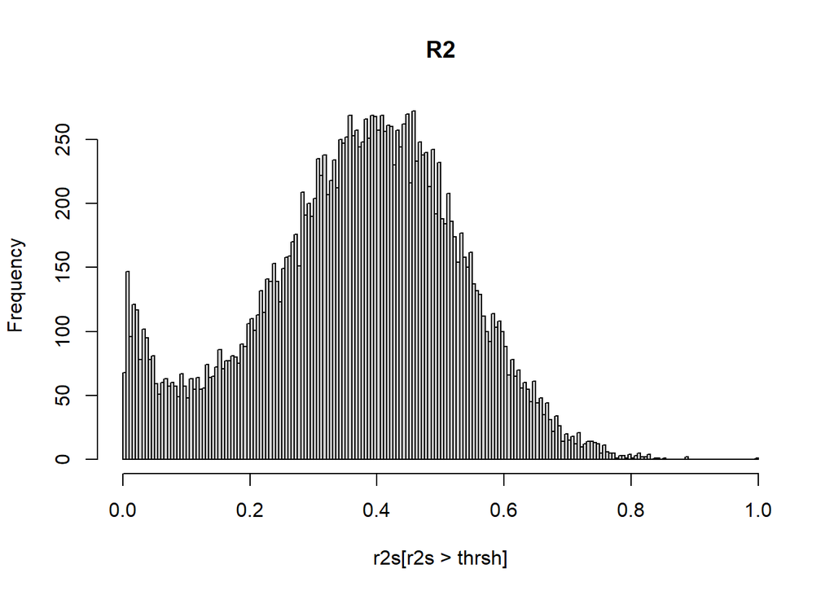

```
##     Min.  1st Qu.   Median     Mean  3rd Qu.     Max.
## 0.001419 0.271176 0.381562 0.368086 0.479179 1.000000
```

```r
saveAs <- "tfMedoidR2"
histsR2(tfResiduals, saveAs, N, dvar)
```

```r
# plotNsave(saveAs, 'tfmedoid-only-r2.png', 'TF-only Model')
```

We clean up in a separate block:

```r
rm(tfMedoid, tfMLM, tfResiduals)
gc()
```

```
##             used   (Mb) gc trigger   (Mb)  max used   (Mb)
## Ncells   6458895  345.0   10866137  580.4  10086763  538.7
## Vcells 220868342 1685.1  663515911 5062.3 574794564 4385.4
```

## Threshing miRs

Mirs are already loaded as a part of matched data and there is no need for pre-processing. We just remove miRs that are zero in many samples for future computational stability.

### Threshing

We run the Thresher:

```r
dim(miRdata)
```

```
## [1] 1146 8895
```

```r
nonzero <- apply(miRdata, 1, function(x) sum(x != 0))
cutoff <- 0.1*ncol(miRdata)
filteredMir <- miRdata[nonzero > cutoff,]
dim(filteredMir)
```

```
## [1]  820 8895
```

```r
f <- file.path(paths$scratch, "threshMir.Rda")
if (file.exists(f)) {
  load(f)
} else {
  set.seed(47053)
  Thresh <- Thresher(t(filteredMir), method="auer.gervini",
                     scale=TRUE, agfun=agDimTwiceMean)
  Reap <- Reaper(Thresh, useLoadings=TRUE, cutoff = 0.35, metric=NULL,
                 linkage="ward.D2", maxSampleGroups = 486)
  save(Thresh, Reap, file = f)
}
rm(f)
```

Let’s look over the results.

```r
Thresh@pcdim  # Number of principal components
```

```
## [1] 24
```

```r
Reap@pcdim    # Number of principal components
```

```
## [1] 24
```

```r
Reap@bic      # Bayes Infomation Criterion
```

```
##      NC=24      NC=25      NC=26      NC=27      NC=28      NC=29      NC=30
## -13809.549 -13916.448 -13803.819 -13698.545 -13596.005 -13853.259 -14002.829
##      NC=31      NC=32      NC=33      NC=34      NC=35      NC=36      NC=37
## -13862.584 -13794.350   4741.357   4901.817   5062.278   5222.739   5383.199
##      NC=38      NC=39      NC=40      NC=41      NC=42      NC=43      NC=44
##   5543.660   5704.121   5864.581   6025.042   6185.503   6345.963   6506.424
##      NC=45      NC=46      NC=47      NC=48      NC=49
##   6666.885   6827.345   6987.806   7148.267 -13399.867
```

```r
Reap@nGroups  # Number of clusters
```

```
## [1] 30
```

Getting to know the clusters:

```r
groups <- predict(Reap@fit)
names(groups) <- rownames(filteredMir)[Reap@keep]
table(groups)
```

```
## groups
##  1  2  3  4  5  6  7  8  9 10 11 12 13 14 15 16 17 18 19 20 21 22 23 24 25 26
## 33 21 14 11 24 13  8 40 11 36  5 19 13  8 14 43 13 30 43  8 43 74 12 15 28 58
## 27 28 29 30
## 24 61 41 38
```

```r
NG <- Reap@nGroups
for (I in 1:NG) {
  cat("\nMIR Cluster", I, ":\n", file=stdout())
  print(names(groups)[groups == I])
}
```

```
##
## MIR Cluster 1 :
##  [1] "hsa-miR-103a-2-5p" "hsa-miR-103a-3p"   "hsa-miR-1248"
##  [4] "hsa-miR-1285-3p"   "hsa-miR-1291"      "hsa-miR-130a-5p"
##  [7] "hsa-miR-148b-5p"   "hsa-miR-151a-5p"   "hsa-miR-17-5p"
## [10] "hsa-miR-186-5p"    "hsa-miR-191-5p"    "hsa-miR-210-3p"
## [13] "hsa-miR-2277-5p"   "hsa-miR-29b-1-5p"  "hsa-miR-324-5p"
## [16] "hsa-miR-339-5p"    "hsa-miR-340-3p"    "hsa-miR-342-3p"
## [19] "hsa-miR-3613-3p"   "hsa-miR-3651"      "hsa-miR-3662"
## [22] "hsa-miR-425-5p"    "hsa-miR-4326"      "hsa-miR-454-5p"
## [25] "hsa-miR-500b-5p"   "hsa-miR-548v"      "hsa-miR-576-5p"
## [28] "hsa-miR-589-3p"    "hsa-miR-616-3p"    "hsa-miR-616-5p"
## [31] "hsa-miR-627-5p"    "hsa-miR-671-5p"    "hsa-miR-93-5p"
##
## MIR Cluster 2 :
```

[output cut: 270 more lines]

```r
mirclusNames <- factor(paste("MIR", groups, sep=""), levels=paste("MIR", 1:NG, sep=""))
mirClusters <- data.frame(Cluster=mirclusNames, row.names = names(groups))
table(mirClusters$Cluster)
```

```
##
##  MIR1  MIR2  MIR3  MIR4  MIR5  MIR6  MIR7  MIR8  MIR9 MIR10 MIR11 MIR12 MIR13
##    33    21    14    11    24    13     8    40    11    36     5    19    13
## MIR14 MIR15 MIR16 MIR17 MIR18 MIR19 MIR20 MIR21 MIR22 MIR23 MIR24 MIR25 MIR26
##     8    14    43    13    30    43     8    43    74    12    15    28    58
## MIR27 MIR28 MIR29 MIR30
##    24    61    41    38
```

We need to save the mediods but this time we save both closest and second closest miRs to the center of each cluster. This is because for GTEx I could not match all of the miR medoids, so I use the second closest instead in those cases:

```r
miRMedoid <- matrix(0, ncol(filteredMir), NG)
miRMedoid2 <- matrix(0, ncol(filteredMir), NG)

colnames(miRMedoid2) <- colnames(miRMedoid) <- 1:ncol(miRMedoid)

f <- file.path(paths$scratch, "miRMedoid.Rda")
g <- file.path(paths$scratch, "miRMedoid2.Rda")

if (file.exists(f)) {
  load(f)
  load(g)
} else {
  for (I in 1:NG) {
    clusterExp <- filteredMir[names(groups)[groups == I],]
    meanZeroClusterExp <- sweep(clusterExp, 2, apply(clusterExp, 2, mean))
    dFromMean <- apply(meanZeroClusterExp, 1, function(x) {sqrt(sum(x*x))})
    mediodGenes <- names(dFromMean)[order(dFromMean)]
    miRMedoid[, I] <- filteredMir[mediodGenes[1],]
    colnames(miRMedoid)[I] <- mediodGenes[1]
    miRMedoid2[, I] <- filteredMir[mediodGenes[2],]
    colnames(miRMedoid2)[I] <- mediodGenes[2]
  }
  save(miRMedoid, file = f)
  save(miRMedoid2, file = g)
}
dim(miRMedoid)
```

```
## [1] 8895   30
```

```r
print(colnames(miRMedoid))
```

```
##  [1] "hsa-miR-576-5p"    "hsa-miR-143-5p"    "hsa-miR-30c-2-3p"
##  [4] "hsa-miR-192-3p"    "hsa-miR-1292-5p"   "hsa-miR-219a-5p"
##  [7] "hsa-miR-449c-5p"   "hsa-miR-24-2-5p"   "hsa-miR-10b-3p"
## [10] "hsa-miR-2355-3p"   "hsa-miR-892a"      "hsa-miR-362-3p"
## [13] "hsa-miR-200a-5p"   "hsa-miR-20b-3p"    "hsa-miR-506-3p"
## [16] "hsa-miR-93-3p"     "hsa-miR-125b-2-3p" "hsa-miR-542-5p"
## [19] "hsa-miR-411-5p"    "hsa-miR-362-5p"    "hsa-miR-374b-5p"
## [22] "hsa-miR-331-3p"    "hsa-miR-96-3p"     "hsa-miR-3605-3p"
## [25] "hsa-miR-590-3p"    "hsa-miR-3909"      "hsa-miR-329-3p"
## [28] "hsa-miR-132-5p"    "hsa-miR-519d-3p"   "hsa-miR-624-5p"
```

```r
dim(miRMedoid2)
```

```
## [1] 8895   30
```

```r
print(colnames(miRMedoid2))
```

```
##  [1] "hsa-miR-340-3p"   "hsa-miR-145-3p"   "hsa-miR-328-3p"   "hsa-miR-194-3p"
##  [5] "hsa-miR-877-3p"   "hsa-miR-153-3p"   "hsa-miR-449b-5p"  "hsa-miR-222-3p"
##  [9] "hsa-miR-196a-5p"  "hsa-miR-34c-3p"   "hsa-miR-891b"     "hsa-miR-188-5p"
## [13] "hsa-miR-200b-3p"  "hsa-miR-18b-3p"   "hsa-miR-509-3-5p" "hsa-miR-425-3p"
## [17] "hsa-miR-497-5p"   "hsa-miR-3065-5p"  "hsa-miR-495-3p"   "hsa-miR-501-3p"
## [21] "hsa-miR-15a-5p"   "hsa-let-7b-3p"    "hsa-miR-548y"     "hsa-miR-3653-3p"
## [25] "hsa-miR-16-1-3p"  "hsa-miR-3680-3p"  "hsa-miR-543"      "hsa-miR-421"
## [29] "hsa-miR-520d-3p"  "hsa-miR-548o-3p"
```

### R2

Next, we fit the linear models only to miRs:

```r
library(ClassComparison)

f <- file.path(paths$scratch, "miRMedoidMLM.Rda")
g <- file.path(paths$scratch, "miRMedoidResiduals.Rda")
if (file.exists(f)) {
  load(f)
  load(g)
} else {
  mirMLM <- MultiLinearModel(Y ~ ., miRMedoid, mRNARest)
  mirResiduals <- mRNARest - t(mirMLM@predictions)
  save(mirMLM,  file = f)
  save(mirResiduals, file = g)
}
rm(f, g)
gc()
```

```
##             used (Mb) gc trigger   (Mb)  max used   (Mb)
## Ncells   6459782  345   10866137  580.4  10086763  538.7
## Vcells 595450201 4543  796299093 6075.3 656828210 5011.3
```

```
## [1] "Percentage of R2 more than the threshold 0 is 1"
```

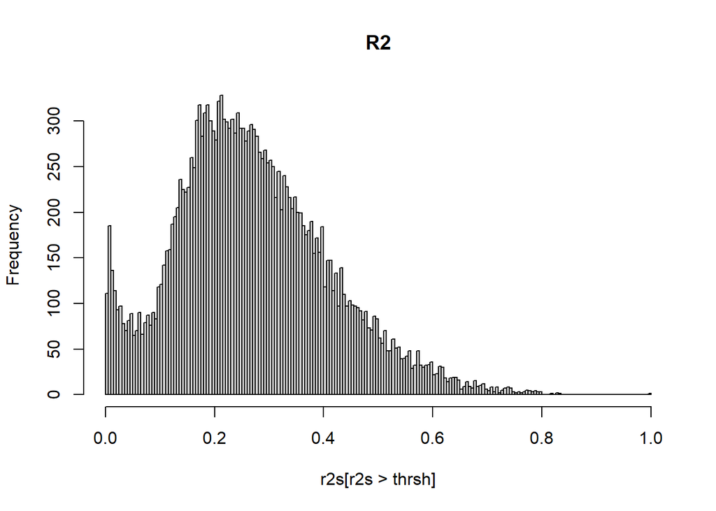

```
##     Min.  1st Qu.   Median     Mean  3rd Qu.     Max.
## 0.001666 0.173103 0.255205 0.269907 0.355076 1.000000
```

```r
saveAs <- "miRMedoidR2"
histsR2(mirResiduals, saveAs, N, dvar)
```

We clean up in a separate block:

```r
rm(miRMedoid, miRMedoid2, mirMLM, mirResiduals)
gc()
```

```
##             used   (Mb) gc trigger   (Mb)  max used   (Mb)
## Ncells   6459508  345.0   10866137  580.4  10086763  538.7
## Vcells 241771001 1844.6  796299093 6075.3 656828210 5011.3
```

## R2 Joint Models

### Simple Joint = (TF, miR) Model

```r
library(ClassComparison)

f <- file.path(paths$scratch, "jointMedoidMLM.Rda")
g <- file.path(paths$scratch, "jointMedoidResiduals.Rda")
if (file.exists(f)) {
  load(f)
  load(g)
} else {
  load(file.path(paths$scratch, "tfMedoid.Rda"))
  load(file.path(paths$scratch, "miRMedoid.Rda"))
  jointMLM <- MultiLinearModel(Y ~ ., cbind(tfMedoid, miRMedoid), mRNARest)
  jointResiduals <- mRNARest - t(jointMLM@predictions)
  save(jointMLM,  file = f)
  save(jointResiduals, file = g)
}
rm(f, g)
gc()
```

```
##             used   (Mb) gc trigger   (Mb)  max used   (Mb)
## Ncells   6459864  345.0   10866137  580.4  10086763  538.7
## Vcells 595472029 4543.1  955638911 7291.0 656828210 5011.3
```

```
## [1] "Percentage of R2 more than the threshold 0 is 1"
```

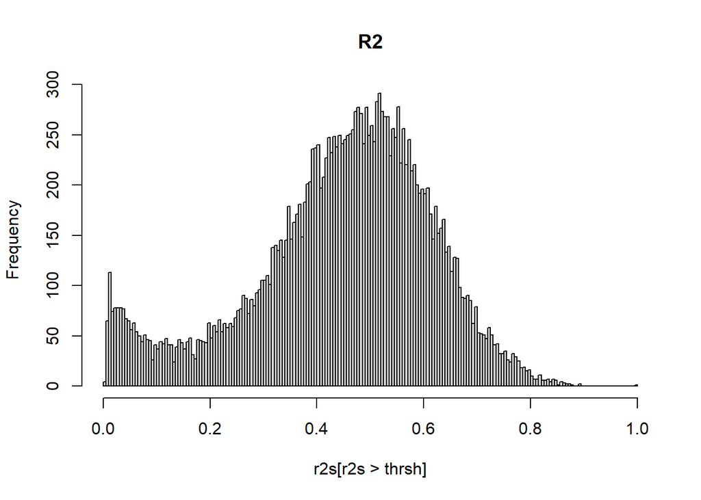

```
##     Min.  1st Qu.   Median     Mean  3rd Qu.     Max.
## 0.003087 0.355582 0.468325 0.445306 0.563001 1.000000
```

```r
saveAs <- "jointMedoidR2"
histsR2(jointResiduals, saveAs, N, dvar)
```

We clean up in a separate block:

```r
rm(tfMedoid, miRMedoid, jointMLM, jointResiduals)
gc()
```

```
##             used   (Mb) gc trigger   (Mb)  max used   (Mb)
## Ncells   6459639  345.0   10866137  580.4  10086763  538.7
## Vcells 241771501 1844.6  764511129 5832.8 656828210 5011.3
```

### Per-Tissue Joint = (TF, miR) Model

An intelligent way of bringing in the tissue in the predition is to have a separate predictors per tissue. We first mean zero the output (using all genes) and then fit a per tissue model (fit the the remaining residuals). First let initialize:

```r
library(ClassComparison)
magicThresh <- 60  #We have 58 features, so at least we need 58 samples.
f <- file.path(paths$scratch, "mean0mRNA.Rda")
if (file.exists(f)) {
  load(f)
} else {
  mean0mRNA <- sweep(mRNARest, 1, apply(mRNARest, 1, mean))
  save(mean0mRNA,  file = f)
}
rm(f)
tissueResiduals <- matrix(0, nrow = nrow(mean0mRNA), ncol = ncol(mean0mRNA))
```

Now, fit one linear model per tissue. For low sample tissues, the model is just an intercept. Some features are constants for some tissues, we remove them to avoid singularity:

```r
f <- file.path(paths$scratch, "jointPerTissueMedoidMLM.Rda")
g <- file.path(paths$scratch, "jointPerTissueMedoidResiduals.Rda")
if (file.exists(f)) {
  load(f)
  load(g)
} else {
  load(file.path(paths$scratch, "tfMedoid.Rda"))
  load(file.path(paths$scratch, "miRMedoid.Rda"))
  tissueMLMList <- list()
  lowSampleTissue <- c() #what type has insufficient sample for MLM
  X <- cbind(tfMedoid, miRMedoid)
  nonDegenFperTissue <- matrix(T, length(levels(cancerType)), ncol(X))
  rownames(nonDegenFperTissue) <- as.character(levels(cancerType))

  for(type in levels(cancerType)){
    print(paste("Fitting", as.character(type)))
    Ts <- (cancerType == type) #Tissue Selector
    if(sum(Ts) < magicThresh){ #Per-tissue average is our predictor
      meanTissuemRNA <- apply(mean0mRNA[,Ts], 1, mean)
      tissueResiduals[,Ts] <- mean0mRNA[,Ts] - meanTissuemRNA
      tissueMLMList[[as.character(type)]] <- meanTissuemRNA #just an intercept
      lowSampleTissue <- c(lowSampleTissue, TRUE)
    } else{
      newX <- X[Ts,]
      #Remove constant features to avoid singularity
      nonDegenF <- apply(newX, 2, min) != apply(newX, 2, max) #none degenerate features
      nonDegenFperTissue[as.character(type),] <- nonDegenF
      newX <- newX[, nonDegenF]
      tissueMLM <- MultiLinearModel(Y ~ ., newX, mean0mRNA[,Ts])
      tissueResiduals[,Ts] <- mean0mRNA[,Ts] - t(tissueMLM@predictions)
      tissueMLMList[[as.character(type)]] <- tissueMLM
      lowSampleTissue <- c(lowSampleTissue, FALSE)
    }

  }
  save(tissueMLMList,  file = f)
  save(tissueResiduals, file = g)
}
rm(f, g)
gc()
```

```
##             used   (Mb) gc trigger   (Mb)  max used   (Mb)
## Ncells   6461892  345.2   10866137  580.4  10086763  538.7
## Vcells 805388583 6144.7 1179937011 9002.3 981556805 7488.7
```

```
## [1] "Percentage of R2 more than the threshold 0 is 1"
```

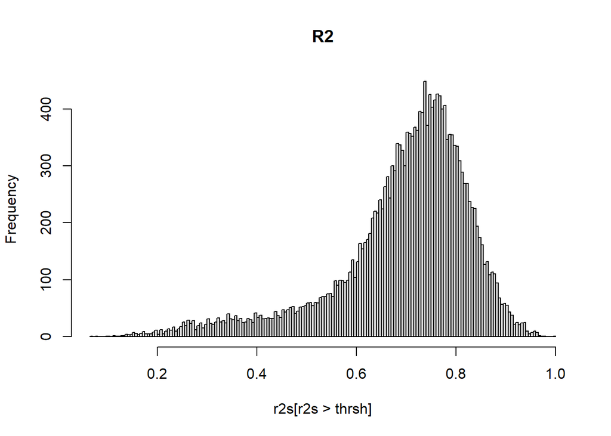

```
##    Min. 1st Qu.  Median    Mean 3rd Qu.    Max.
## 0.06893 0.64140 0.72302 0.69454 0.78431 1.00000
```

```r
saveAs <- "tissueMedoidR2"
histsR2(tissueResiduals, saveAs, N, dvar)
```

```r
rm(tfMedoid, miRMedoid, tissueMLMList, tissueResiduals, mean0mRNA)
gc()
```

```
##             used   (Mb) gc trigger   (Mb)  max used   (Mb)
## Ncells   6459675  345.0   10866137  580.4  10086763  538.7
## Vcells 241771899 1844.6  943949609 7201.8 981556805 7488.7
```

# Appendix